# Predict the Next Word

YH  
16/03/2020

Around the world, people are spending an increasing amount of time on their mobile devices for email, social networking, banking and a whole range of other activities. But typing on mobile devices can be a serious pain. SwiftKey, our corporate partner in this capstone, builds a smart keyboard that makes it easier for people to type on their mobile devices. One cornerstone of their smart keyboard is predictive text models.

### General workflow of the App

The main aim of this app is to predict the next word that is likely to come up

The data used for this app is from three English sources: Blogs, News and Twitters. We made use of the r package “quanteda” to explore and clean up the data, and build the App with [n-grams](https://en.wikipedia.org/wiki/N-gram) model

The general workflow is:

1. Load in data
2. Sampling data
3. Tokenize
4. Builiding models

### Example code for data clean up and tokenization

```r
  corpus_all<-str_remove_all(corpus_all,"#|@|-")
  tokens<-tokens(tolower(corpus_all),
                 remove_punct = TRUE,
                 remove_numbers = TRUE,
                 remove_url = TRUE,
                 remove_symbols = TRUE)
  tokens_clean<-tokens_wordstem(tokens_tolower(tokens))
  rm(tokens)

#Generate n-grams and stored in variables
  tokens_1<-tokens_ngrams(tokens_clean, n=1)
  tokens_2<-tokens_ngrams(tokens_clean, n=2)
  tokens_3<-tokens_ngrams(tokens_clean, n=3)
  saveRDS(tokens_clean, "tokens_clean.RDS")
  rm(tokens_clean)
```

### 50 most frequently used 3-word combinations

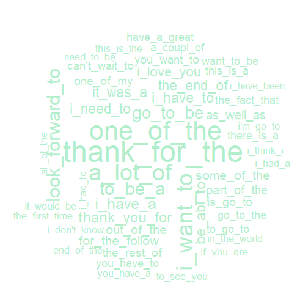

### To use the App

The app can be found at

https://yh-shiny.shinyapps.io/PredictNextWord/

It is easy and handy to use, just need to follow 3 steps

1. Key in a sentence you would like to enquire on the left-hand side
2. Slide the slide bar to indicate how many alternative options you would like to see
3. You may see the prediction on the Main Panel

So, Enjoy!